# si618hw2report_wanjun

JW

2016/11/07

# SI 618 Homework 2

## Load and Cleanse Data (5 points)

First load the TSV data file created in part 1 into R using the **read.table()** function. Then apply listwise deletion to remove records with missing data and display the first 15 rows of the data frame.

```
##                                 name           city state stars
## 1  Southern California Medical Group    Los Angeles    CA   3.5
## 2             Harvard Square Shiatsu      Cambridge    MA   4.0
## 3           Faith & Glory Collective      Kitchener    ON   4.0
## 4            Von's Records & Posters West Lafayette    IN   3.5
## 5                          JP's Java         Austin    TX   3.5
## 6           Cooper Brown Real Estate        Atlanta    GA   3.5
## 7        Winberie's Restaurant & Bar      Princeton    NJ   3.5
## 8                       Joe's Tavern         Cohoes    NY   4.0
## 9                          Starbucks   Philadelphia    PA   3.0
## 10                    Vitamin Shoppe        Houston    TX   5.0
## 11               Parties Over Boston         Boston    MA   5.0
## 12                 Nierman Preschool       La Jolla    CA   4.0
## 13           Pasadena Towers Parking       Pasadena    CA   5.0
## 14                       Ryan's Wake           Troy    NY   3.5
```

[output cut: 17 more lines]

## Histograms of Star Ratings (10 points)

Using the **qplot()** function, plot histograms of the distribution of star ratings, faceted by state, using a bin width of 0.5.

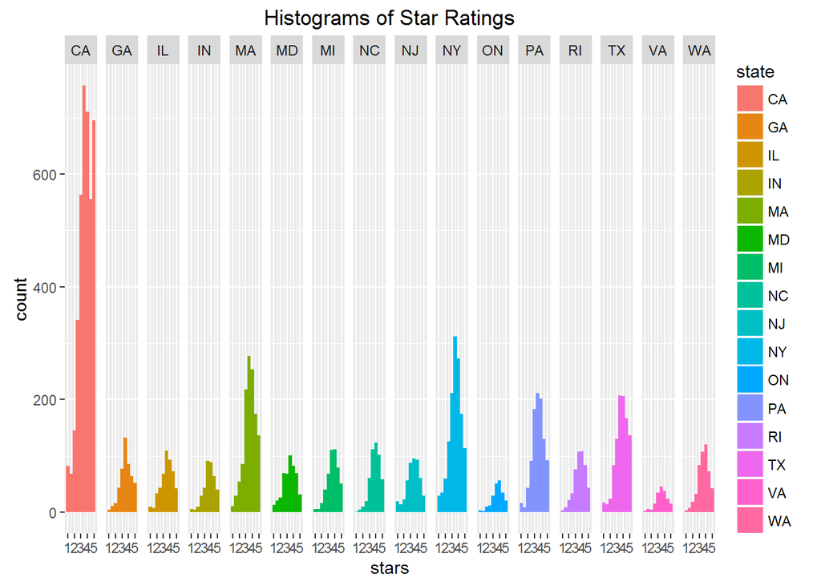

## Histograms of Review Counts (10 points)

Using the **qplot()** function, plot the distribution of review counts as a histogram. First, plot a histogram that simply uses the raw values in review_count:

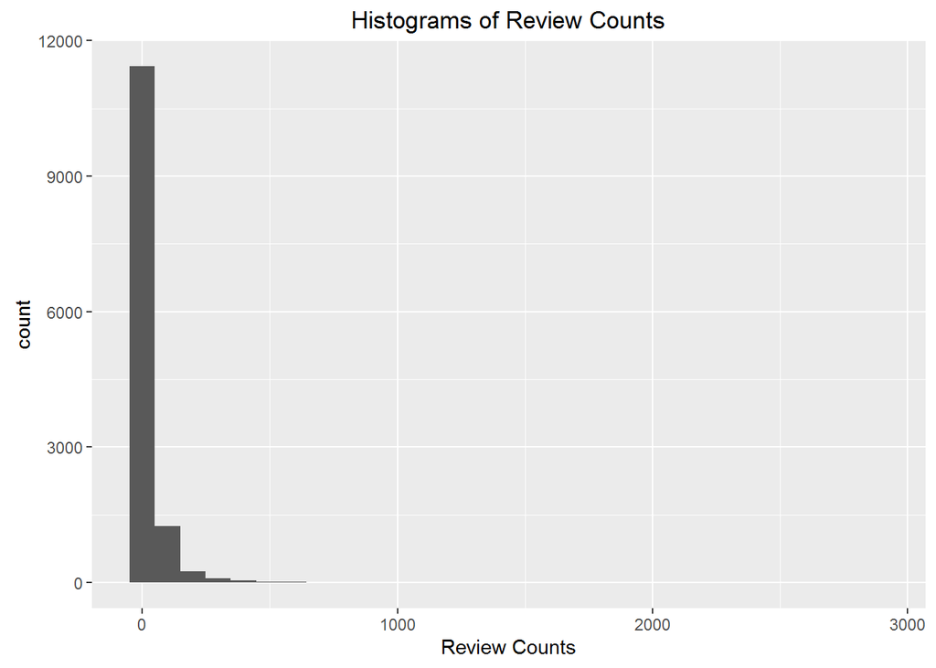

Then for comparison, plot a histogram that transforms the review counts using the log() function.

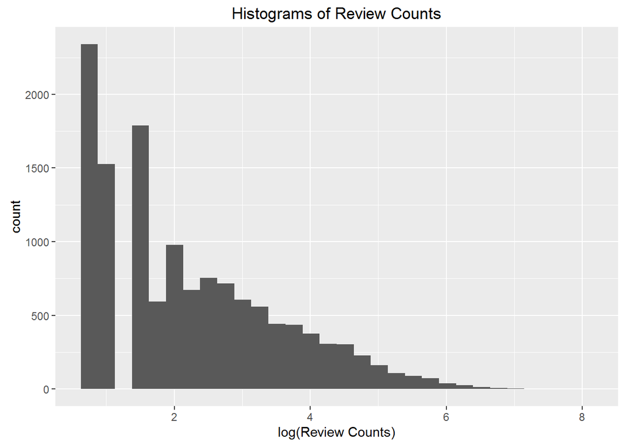

We can see the distribution of review counts has a long tail. To zoom in on the part of the distribution with review counts between 0 and 100, use the **subset()** function to select just the data with review count <= 100. And then plot the (non-log-transformed) histogram again using a bin width of 2, and also include a overlay that plots a probability density function over the review counts. (Recall that you can produce an overlay by passing a list of geometry names to the geom= argument in qplot().)

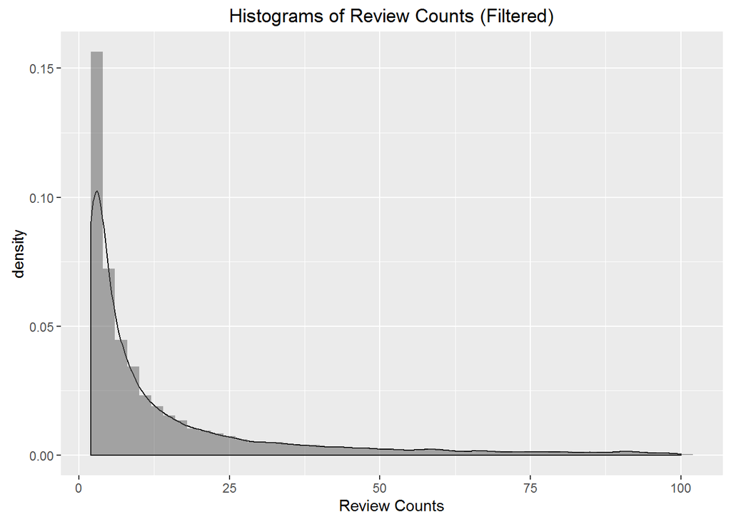

## Boxplot of Star Ratings by States (5 points)

Here, map the value of the state variable to the “color” and “fill” aesthetics, and plot a boxplot of the star ratings by state.

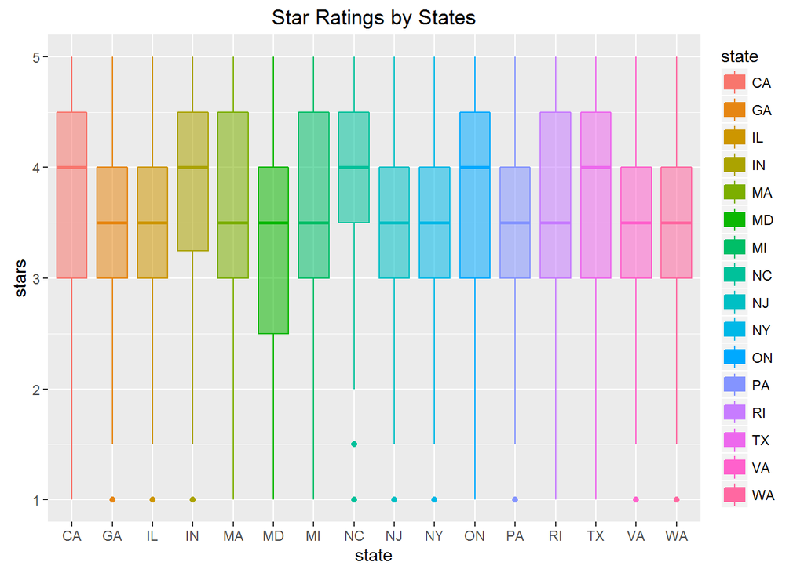

## Jittered Plot of Star Ratings by State (5 points)

Here, map the value of the state variable to the “color” and “fill” aesthetics, and plot a jittered point plot of the star ratings by state.

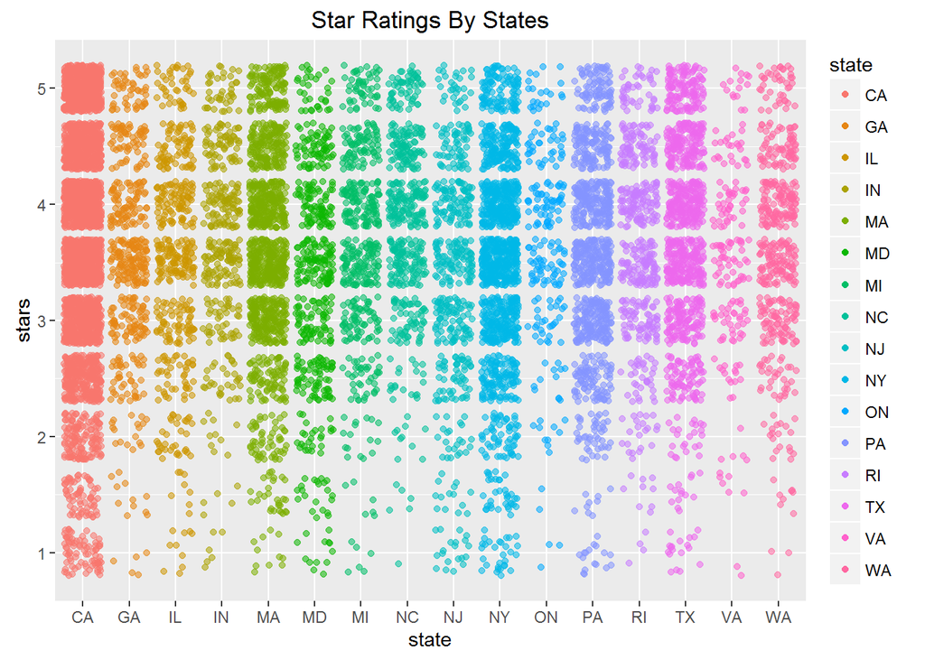

## Bar Chart of Number of Businesses by State (5 points)

Plot a bar chart showing the number of businesses in the dataset for each state.

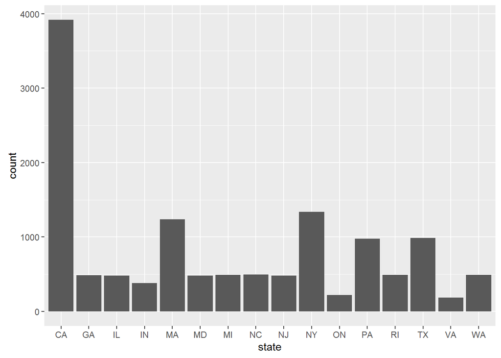

## Scatterplot of Stars and Review Counts (5 points)

Plot a scatterplot showing the star rating and review count for all businesses, mapping the state variable to the color aesthetic.

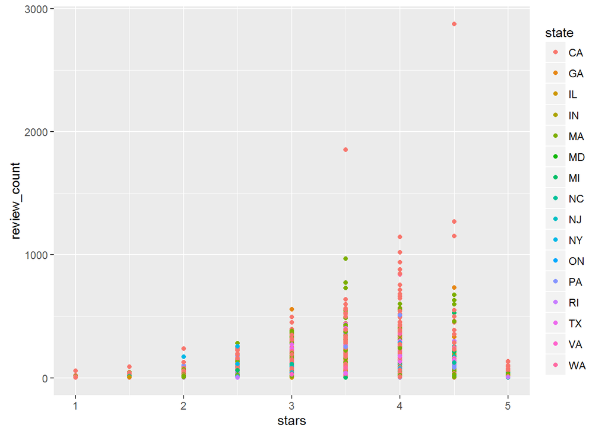

## Slice and Dice Data with plyr

### Subsetting Data (15 points)

We first rank the business in each city for each main category and display the first 20 results of the resulting list.

```
##                                         name    city state stars
## 1  University of Maryland University College Adelphi    MD   3.5
## 2                              Basil's Pizza Adelphi    MD   3.0
## 3                  The Capital Distirct YMCA  Albany    NY   4.5
## 4               Wolfert's Roost Country Club  Albany    NY   3.5
## 5                             Saati Catering  Albany    NY   4.0
## 6                              Price Chopper  Albany    NY   2.5
## 7               Menands Mobil Service Center  Albany    NY   4.0
## 8                         Genoa Importing Co  Albany    NY   4.5
## 9                     Mancini's Deli & Pizza  Albany    NY   2.0
## 10                             The Lamp Post  Albany    NY   2.5
## 11  Albany Rural Cemetery Chapel & Mausoleum  Albany    NY   5.0
## 12                       20 Toes Cat Sitting  Albany    NY   5.0
## 13        Albany General Services Department  Albany    NY   3.5
## 14                Hampshire Bicycle Exchange Amherst    MA   3.0
```

[output cut: 27 more lines]

Then the top 5 ranked businesses in each city for each main category are found. We’re interested in the top 5 businesses that have a main category of “Thai” in each city. The data should be ordered by city name, and then by rank. The result is listed below.

```
##                city                            name rank
## 1           Amherst                     Thai Corner    1
## 2         Ann Arbor                         No Thai    1
## 3         Ann Arbor                    Siam Cuisine    2
## 4         Ann Arbor                         No Thai    3
## 5           Atlanta           Tamarind Thai Cuisine    1
## 6           Atlanta                           Spoon    2
## 7           Atlanta              Tin Drum Asia Cafe    3
## 8           Atlanta                      Zen on Ten    4
## 9           Atlanta The Tenth Thai Cuisine & Lounge    5
## 10           Austin                      Thai Spice    1
## 11           Austin                     Ming's Cafe    2
## 12           Austin          Thai Noodles Etc House    3
## 13           Austin          Crave Thai & Sushi bar    4
## 14         Berkeley                     Satay House    1
```

[output cut: 91 more lines]

### Summarize Data (5 points)

Compute the mean star ratings grouped by state, for all the selected top 5 Thai restaurants selected in the previous section. Plot the mean star rating using a point chart, use the size of the point to indicate the mean review count for that state’s restaurants, and sort the states by descending mean rating.

A very useful way to control the order in which the states are sorted in the plot is the **reorder()** function.

- The **reorder** function operates on a variable and takes three parameters:
  - The variable whose factors you want to reorder
  - A numeric vector of equal length (i.e. that has one value per possible value of the given variable. In this case, one value per possible state.)
  - A function to apply to the numeric vector (optional: the identity function if not specified)

Since R treats each unique state string like an unordered factor, you can use reorder() to impose an ordering on the states according to the numeric vector you provide.  
We’ll cover factors more in an upcoming class.

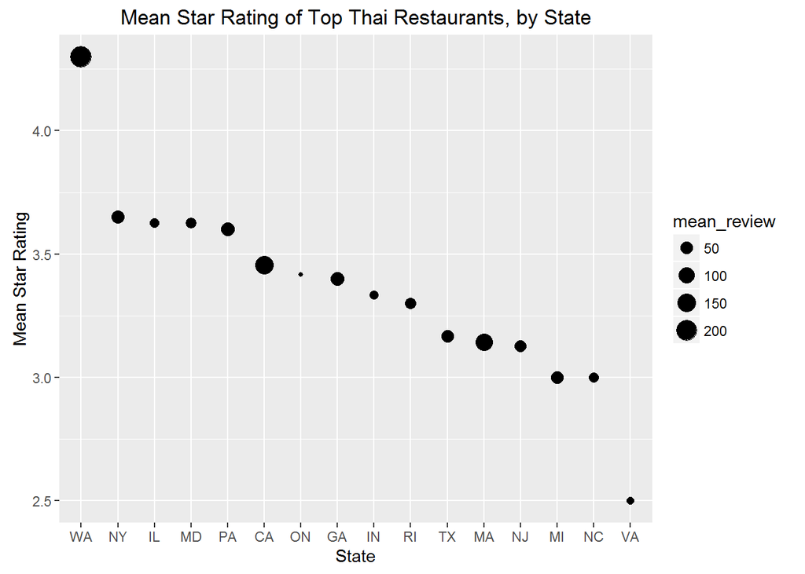